# Exploratory Analysis

Group 6

5/17/2020

# Overview

| State | Mean (percentage) | Standard Deviation |
| --- | --- | --- |
| Ohio | 20.16875 | 3.138305 |
| Nevada | 19.83750 | 3.527582 |
| Delaware | 17.95625 | 3.257191 |
| Rhode Island | 16.10625 | 3.164905 |
| Arizona | 15.23750 | 3.386222 |

# Distribution of Variables

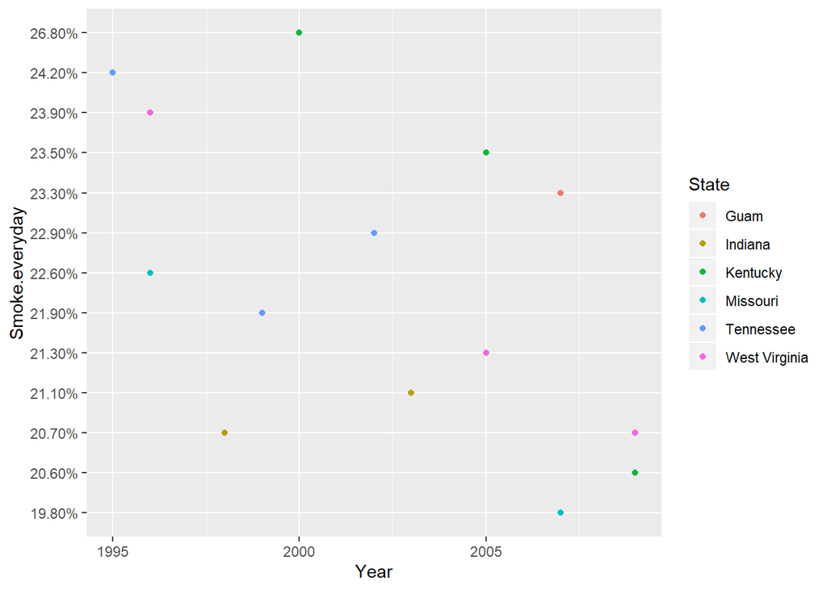

## Nationwide Averages of Everyday Smokers Over 15 Years

This graph examines the nationwide averages of everyday smokers for each year in the dataset. Luckily, this dataset already included the averages under a State name of “Nationwide (States, DC, and Territories)”. The graph shows that the nationwide average of everyday smokers has decreased by roughly 7.60% over 15 years, suggesting that measures to combat smoking such as awareness campaigns and taxing smoking products have been relatively effective.

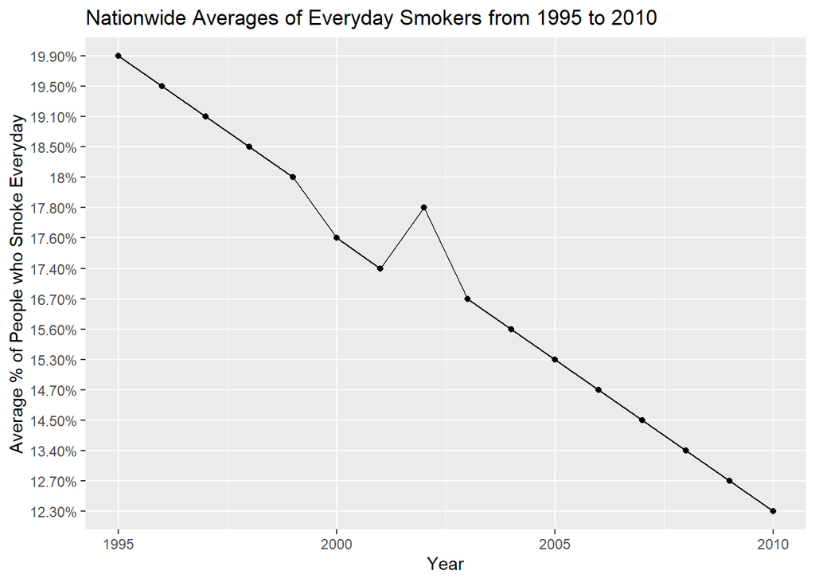

# Relationships Between Variables

## Nationwide Averages Across All Smoking Categories Over 15 Years

This chart illustrates the nationwide averages across the four smoking usage categories included in the dataset from 1995 to 2010. Although a simple visualization, it still manages to display the relationship between two continuous variables (time and percent) and one categorical variable (smoking activity) nicely. And its easy to see how each group has fared over time, significant trends, and comparisons admist different varaibles. For instance, there’s an evident increase for those who have never smoked in 2004. Which also observes decreases for individuals who were former smokers and everyday smokers. This can be correlated to the successful Anti-Smoking efforts in America for that year.

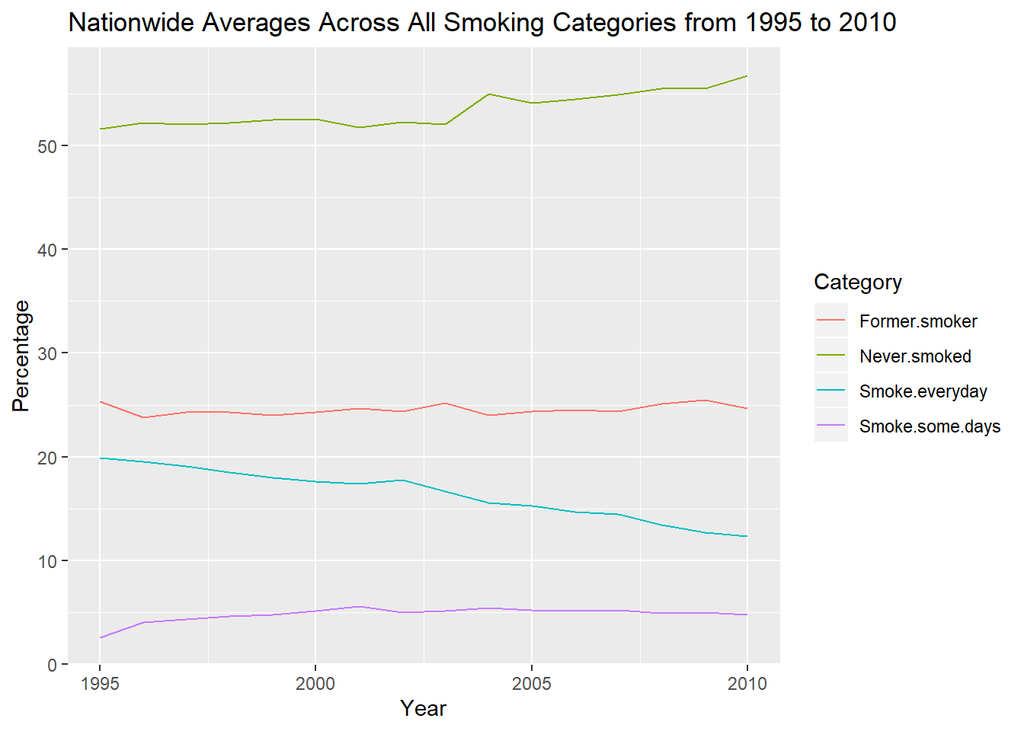

## Smoking Behavior Changes Over 15 Years

This graph shows the difference in smoking behavior percentages between 1995 and 2010 in the United States of America. In 1995, there was a higher percentage of people who were daily smokers compared to that in 2010. However, there were fewer people smoking some days in 1995 compared to 2010. The percentage of former smokers was very similar between the two years, with 1995 experiencing a slightly higher percentage. In 2010, there was a higher percentage of people who never smoked compared to 1995. This shows that while there might have been a slight decrease in smoking behavior over time, smoking is still prevalent within our society.

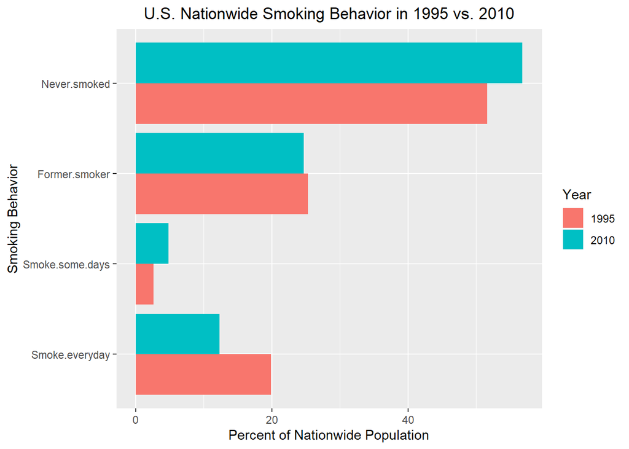